# Machine Learning 2019: Feature Selection

Sonali Narang

October 24, 2019

## Feature Selection

In machine learning, feature selection is the process of choosing variables that are useful in predicting the response variable. Selecting the right features in your data can mean the difference between mediocre performance with long training times and great performance with short training times that are less computationally intensive.

Often, data can contain attributes that are highly correlated with each other or not useful in helping predict our response variable. Many methods perform better if such variables are removed. Feature selection is usually imporant to implement during the data pre-processing steps of machine learning.

## The Breast Cancer Dataset

699 Observations, 11 variables Predictor Variable: Class- benign or malignant

```r
data(BreastCancer)
head(BreastCancer)
```

|  | Id | Cl.thickness | Cell.size | Cell.shape | Marg.adhesion | Epith.c.size | Bare.nuclei | Bl.cromatin | Normal.nucleoli | Mitoses | Class |
| --- | --- | --- | --- | --- | --- | --- | --- | --- | --- | --- | --- |
| 1 | 1000025 | 5 | 1 | 1 | 1 | 2 | 1 | 3 | 1 | 1 | benign |
| 2 | 1002945 | 5 | 4 | 4 | 5 | 7 | 10 | 3 | 2 | 1 | benign |
| 3 | 1015425 | 3 | 1 | 1 | 1 | 2 | 2 | 3 | 1 | 1 | benign |
| 4 | 1016277 | 6 | 8 | 8 | 1 | 3 | 4 | 3 | 7 | 1 | benign |
| 5 | 1017023 | 4 | 1 | 1 | 3 | 2 | 1 | 3 | 1 | 1 | benign |
| 6 | 1017122 | 8 | 10 | 10 | 8 | 7 | 10 | 9 | 7 | 1 | malignant |

```r
dim(BreastCancer)
```

```
## [1] 699  11
```

```r
summary(BreastCancer$Class)
```

```
##    benign malignant
##       458       241
```

## Feature Selection Using Filter Methods: Pearson’s Correlation

Filter Methods are generally used as a preprocessing step so the selection of features is independednt of any machine learning algorithms. Features are selected on the basis of their scores in various statistical tests for their correlation with the outcome variable.

Below we will identify attributes that are highly correlated using Pearson’s correlation which is a measure for quantifying linear dependence between X and Y. Ranges between -1 and 1.

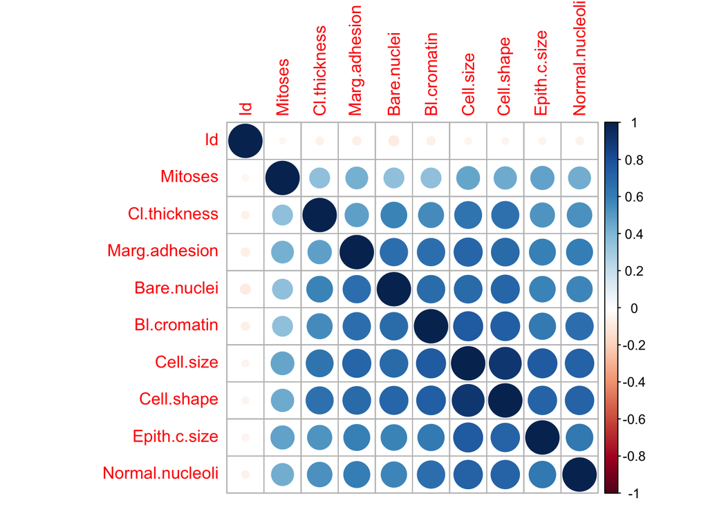

```r
BreastCancer_num = transform(BreastCancer, Id = as.numeric(Id),
                         Cl.thickness = as.numeric(Cl.thickness),
                         Cell.size = as.numeric(Cell.size),
                         Cell.shape = as.numeric(Cell.shape),
                         Marg.adhesion = as.numeric(Marg.adhesion),
                         Epith.c.size = as.numeric(Epith.c.size),
                         Bare.nuclei = as.numeric(Bare.nuclei),
                         Bl.cromatin = as.numeric(Bl.cromatin),
                         Normal.nucleoli = as.numeric(Normal.nucleoli),
                         Mitoses = as.numeric(Mitoses))

BreastCancer_num[is.na(BreastCancer_num)] = 0

#calculate correlation matrix using pearson correlation (others include spearman and kendall)
correlation_matrix = cor(BreastCancer_num[,1:10])

#visualize correlation matrix
corrplot(correlation_matrix, order = "hclust")
```

```r
#apply correlation filter of 0.7
highly_correlated <- colnames(BreastCancer[, -1])[findCorrelation(correlation_matrix, cutoff = 0.7, verbose = TRUE)]
```

```
## Compare row 3  and column  4 with corr  0.907
##   Means:  0.631 vs 0.477 so flagging column 3
## Compare row 4  and column  8 with corr  0.736
##   Means:  0.588 vs 0.447 so flagging column 4
## All correlations <= 0.7
```

```r
#which features are highly correlated and can be removed
highly_correlated
```

```
## [1] "Cell.shape"    "Marg.adhesion"
```

## Feature Selection Using Wrapper Methods: Recursive Feature Elimination (RFE)

Wrapper methods are a bit more computationally intensive since we will select features based on a specific machine learning algorith.

The RFE function implements backwards selection of predictors based on predictor importance ranking. The predictors are ranked and the less important ones are sequentially eliminated prior to modeling. The goal is to find a subset of predictors that can be used to produce an accurate model.

```r
##  RECURSIVE FEATURE ELIMINATION

data(BreastCancer)
BreastCancer_num = transform(BreastCancer, Id = as.numeric(Id),
                         Cl.thickness = as.numeric(Cl.thickness),
                         Cell.size = as.numeric(Cell.size),
                         Cell.shape = as.numeric(Cell.shape),
                         Marg.adhesion = as.numeric(Marg.adhesion),
                         Epith.c.size = as.numeric(Epith.c.size),
                         Bare.nuclei = as.numeric(Bare.nuclei),
                         Bl.cromatin = as.numeric(Bl.cromatin),
                         Normal.nucleoli = as.numeric(Normal.nucleoli),
                         Mitoses = as.numeric(Mitoses))

BreastCancer_num[is.na(BreastCancer_num)] = 0

#define the control
control = rfeControl(functions = caretFuncs, number = 2)

# run the RFE algorithm
results = rfe(BreastCancer_num[,1:10], BreastCancer_num[,11], sizes = c(2,5,9), rfeControl = control, method = "svmRadial")

results
```

```
##
## Recursive feature selection
##
## Outer resampling method: Bootstrapped (2 reps)
##
## Resampling performance over subset size:
##
##  Variables Accuracy  Kappa AccuracySD  KappaSD Selected
##          2   0.9501 0.8897   0.013296 0.028400
##          5   0.9699 0.9342   0.008996 0.019954        *
##          9   0.9561 0.9044   0.010569 0.022097
##         10   0.9500 0.8916   0.001980 0.003923
##
## The top 5 variables (out of 5):
##    Cell.shape, Cell.size, Bl.cromatin, Bare.nuclei, Epith.c.size
```

```r
results$variables
```

| benign | malignant | Overall | var | Variables | Resample |
| --- | --- | --- | --- | --- | --- |
| 0.9738499 | 0.9738499 | 0.9738499 | Cell.shape | 10 | Resample1 |
| 0.9724034 | 0.9724034 | 0.9724034 | Cell.size | 10 | Resample1 |
| 0.9445738 | 0.9445738 | 0.9445738 | Bl.cromatin | 10 | Resample1 |
| 0.9440812 | 0.9440812 | 0.9440812 | Bare.nuclei | 10 | Resample1 |
| 0.9258850 | 0.9258850 | 0.9258850 | Epith.c.size | 10 | Resample1 |
| 0.9104251 | 0.9104251 | 0.9104251 | Cl.thickness | 10 | Resample1 |
| 0.8911137 | 0.8911137 | 0.8911137 | Marg.adhesion | 10 | Resample1 |
| 0.8848796 | 0.8848796 | 0.8848796 | Normal.nucleoli | 10 | Resample1 |
| 0.7195058 | 0.7195058 | 0.7195058 | Mitoses | 10 | Resample1 |
| 0.5872416 | 0.5872416 | 0.5872416 | Id | 10 | Resample1 |

[output cut: 42 more lines]

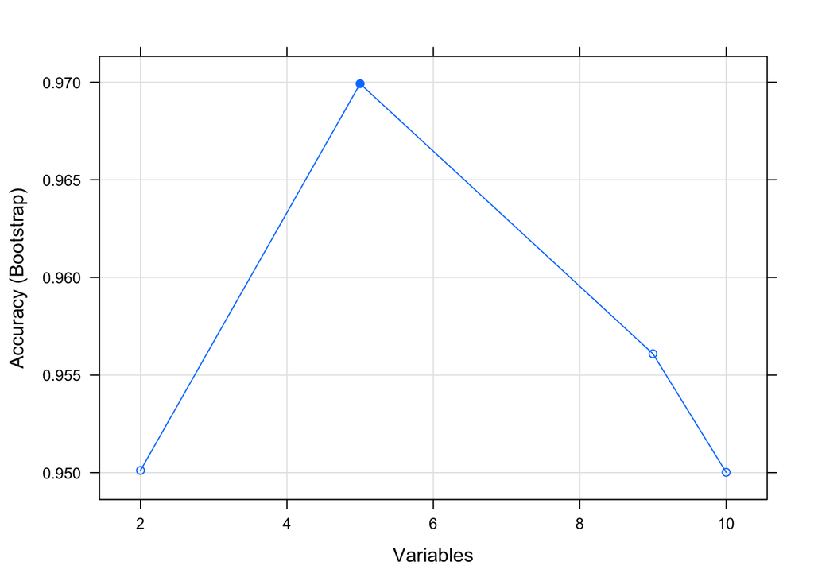

```r
plot(results, type=c('g', 'o'))
```

```r
predictors(results)
```

```
## [1] "Cell.shape"   "Cell.size"    "Bl.cromatin"  "Bare.nuclei"
## [5] "Epith.c.size"
```

## Feature Selection Using Embedded Methods: Lasso

Least Absolute Shrinkage and Selection Operator (LASSO) regression

```r
##  LASSO

set.seed(24)

#convert data
x <- as.matrix(BreastCancer_num[,1:10])
y <- as.double(as.matrix(ifelse(BreastCancer_num[,11]=='benign', 0, 1)))

#fit Lasso model
cv.lasso <- cv.glmnet(x, y, family='binomial', alpha=1, parallel=TRUE, standardize=TRUE, type.measure='auc')
```

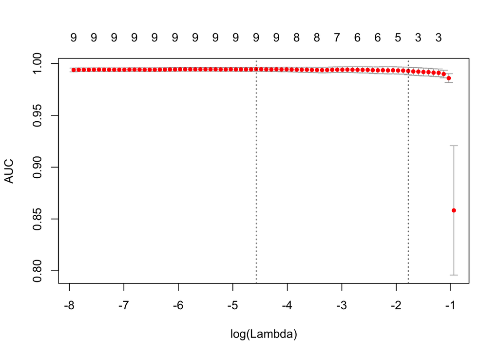

```r
plot(cv.lasso)
```

```r
cat('Min Lambda: ', cv.lasso$lambda.min, '\n 1Sd Lambda: ', cv.lasso$lambda.1se)
```

```
## Min Lambda:  0.01033845
##  1Sd Lambda:  0.1684909
```

```r
df_coef <- round(as.matrix(coef(cv.lasso, s=cv.lasso$lambda.min)), 2)

# See all contributing variables
df_coef[df_coef[, 1] != 0, ]
```

```
##     (Intercept)    Cl.thickness       Cell.size      Cell.shape
##           -6.95            0.38            0.10            0.24
##   Marg.adhesion    Epith.c.size     Bare.nuclei     Bl.cromatin
##            0.11            0.04            0.34            0.28
## Normal.nucleoli         Mitoses
##            0.12            0.10
```

## Feature Selection Using Embedded Methods: RandomForest

Random Forest Importance function and caret package’s varImp functions perform similarly.

```r
#data
data(BreastCancer)
train_size <- floor(0.75 * nrow(BreastCancer))
set.seed(24)
train_pos <- sample(seq_len(nrow(BreastCancer)), size = train_size)

#convert to numeric
BreastCancer_num = transform(BreastCancer, Id = as.numeric(Id),
                         Cl.thickness = as.numeric(Cl.thickness),
                         Cell.size = as.numeric(Cell.size),
                         Cell.shape = as.numeric(Cell.shape),
                         Marg.adhesion = as.numeric(Marg.adhesion),
                         Epith.c.size = as.numeric(Epith.c.size),
                         Bare.nuclei = as.numeric(Bare.nuclei),
                         Bl.cromatin = as.numeric(Bl.cromatin),
                         Normal.nucleoli = as.numeric(Normal.nucleoli),
                         Mitoses = as.numeric(Mitoses))

BreastCancer_num[is.na(BreastCancer_num)] = 0

train_classification <- BreastCancer_num[train_pos, ]
test_classification <- BreastCancer_num[-train_pos, ]

#fit a model
rfmodel = randomForest(Class ~ Id + Cl.thickness + Cell.size + Cell.shape + Marg.adhesion + Epith.c.size + Bare.nuclei + Bl.cromatin + Normal.nucleoli +  Mitoses, data=train_classification,  importance = TRUE, oob.times = 15, confusion = TRUE)

#rank features based on importance
importance(rfmodel)
```

```
##                    benign malignant MeanDecreaseAccuracy MeanDecreaseGini
## Id              -3.017707  7.020745             5.040407         5.220543
## Cl.thickness    19.473720 19.030138            23.237756        14.701877
## Cell.size       13.565464 16.312607            19.965536        55.072212
## Cell.shape       9.195184 17.016449            18.768314        45.538135
## Marg.adhesion    8.077613  9.128484            11.779622         7.893144
## Epith.c.size    10.017570  5.693886            11.456708        20.360445
## Bare.nuclei     18.961710 27.729723            30.097789        48.522918
## Bl.cromatin      7.793755 14.815715            16.712754        24.206998
## Normal.nucleoli 13.706432  7.932659            15.065708        14.687062
## Mitoses          6.986875  3.429617             7.769080         1.709094
```

^^ larger change here indicates greater importance of the feature in classificiation

## Homework

**Part I:** Compare the most important features from at least 2 different classes of feature selection methods covered in this tutorial with any reasonable machine learning dataset from mlbench. Do these feature selection methods provide similar results?

```r
data(PimaIndiansDiabetes)
head(PimaIndiansDiabetes)
```

|  | pregnant | glucose | pressure | triceps | insulin | mass | pedigree | age | diabetes |
| --- | --- | --- | --- | --- | --- | --- | --- | --- | --- |
| 1 | 6 | 148 | 72 | 35 | 0 | 33.6 | 0.627 | 50 | pos |
| 2 | 1 | 85 | 66 | 29 | 0 | 26.6 | 0.351 | 31 | neg |
| 3 | 8 | 183 | 64 | 0 | 0 | 23.3 | 0.672 | 32 | pos |
| 4 | 1 | 89 | 66 | 23 | 94 | 28.1 | 0.167 | 21 | neg |
| 5 | 0 | 137 | 40 | 35 | 168 | 43.1 | 2.288 | 33 | pos |
| 6 | 5 | 116 | 74 | 0 | 0 | 25.6 | 0.201 | 30 | neg |

```r
str(PimaIndiansDiabetes)
```

```
## 'data.frame':    768 obs. of  9 variables:
##  $ pregnant: num  6 1 8 1 0 5 3 10 2 8 ...
##  $ glucose : num  148 85 183 89 137 116 78 115 197 125 ...
##  $ pressure: num  72 66 64 66 40 74 50 0 70 96 ...
##  $ triceps : num  35 29 0 23 35 0 32 0 45 0 ...
##  $ insulin : num  0 0 0 94 168 0 88 0 543 0 ...
##  $ mass    : num  33.6 26.6 23.3 28.1 43.1 25.6 31 35.3 30.5 0 ...
##  $ pedigree: num  0.627 0.351 0.672 0.167 2.288 ...
##  $ age     : num  50 31 32 21 33 30 26 29 53 54 ...
##  $ diabetes: Factor w/ 2 levels "neg","pos": 2 1 2 1 2 1 2 1 2 2 ...
```

```r
PimaIndiansDiabetes[is.na(PimaIndiansDiabetes)] = 0
```

Method 1:

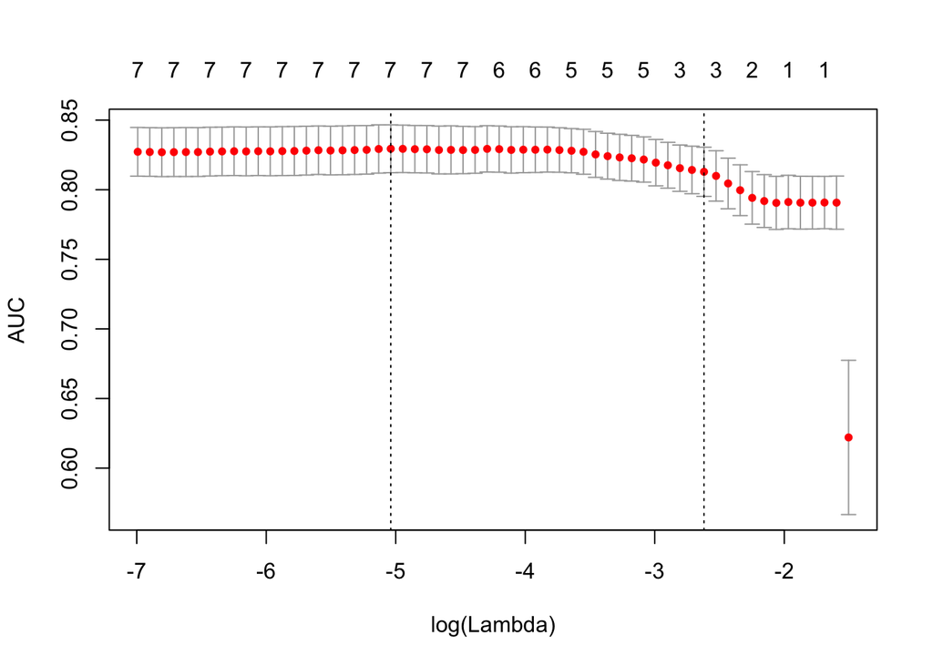

```r
## Feature Selection Using Embedded Methods: Lasso

set.seed(15)

#convert data
x <- as.matrix(PimaIndiansDiabetes[,1:8])
y <- as.double(as.matrix(ifelse(PimaIndiansDiabetes[,9]=='pos', 0, 1)))

#fit Lasso model
cv.lasso <- cv.glmnet(x, y, family='binomial', alpha=1, parallel=TRUE, standardize=TRUE, type.measure='auc')

plot(cv.lasso)
```

```r
cat('Min Lambda: ', cv.lasso$lambda.min, '\n 1Sd Lambda: ', cv.lasso$lambda.1se)
```

```
## Min Lambda:  0.006482836
##  1Sd Lambda:  0.07282326
```

```r
df_coef <- round(as.matrix(coef(cv.lasso, s=cv.lasso$lambda.min)), 2)

# See all contributing variables
df_coef[df_coef[, 1] != 0, ]
```

```
## (Intercept)    pregnant     glucose    pressure        mass    pedigree
##        7.80       -0.11       -0.03        0.01       -0.08       -0.78
##         age
##       -0.01
```

Method 2:

```r
## Feature Selection Using Embedded Methods: RandomForest

train_size <- floor(0.75 * nrow(PimaIndiansDiabetes))
set.seed(24)
train_pos <- sample(seq_len(nrow(PimaIndiansDiabetes)), size = train_size)



PimaIndiansDiabetes[is.na(PimaIndiansDiabetes)] = 0

train_classification <- PimaIndiansDiabetes[train_pos, ]
test_classification <- PimaIndiansDiabetes[-train_pos, ]

#fit a model
rfmodel = randomForest(diabetes ~ glucose + pregnant + pressure + triceps + insulin + mass + pedigree + age,
                       data=train_classification,  importance = TRUE, oob.times = 15, confusion = TRUE)

#rank features based on importance
importance(rfmodel)
```

```
##                neg       pos MeanDecreaseAccuracy MeanDecreaseGini
## glucose  30.970629 32.516205            40.521562         72.13800
## pregnant 13.091419  2.176403            12.369781         22.63690
## pressure  4.873567 -1.258797             2.847811         23.74811
## triceps   5.080423  2.445255             5.709976         18.93266
## insulin   7.064896  1.661299             6.777617         20.70159
## mass     14.093280  9.968042            17.507662         41.09226
## pedigree  6.764849  1.704640             6.060819         32.62841
## age      15.249217  8.848204            17.801690         36.17501
```

**Part II:** Attempt a feature selection method not covered in this tutorial (backward elimination, forward propogation, etc.)

Used wrapper method: feature selection by simluated annealing. This approach tests the model on random subsets of features to determine the best features on which to build the model

```r
ctrl <- safsControl(functions = treebagSA)
```

```r
obj <- safs(x = PimaIndiansDiabetes[,1:8],
            y = PimaIndiansDiabetes[,9],
            iters = 100,
            safsControl = ctrl)
obj
```

```
##
## Simulated Annealing Feature Selection
##
## 768 samples
## 8 predictors
## 2 classes: 'neg', 'pos'
##
## Maximum search iterations: 100
##
## Internal performance values: Accuracy, Kappa
## Subset selection driven to maximize internal Accuracy
##
## External performance values: Accuracy, Kappa
## Best iteration chose by maximizing external Accuracy
## External resampling method: Cross-Validated (10 fold, repeated 1 times)
##
## During resampling:
##   * the top 5 selected variables (out of a possible 8):
##     glucose (100%), age (80%), mass (80%), pedigree (80%), pregnant (70%)
##   * on average, 5.4 variables were selected (min = 1, max = 8)
##
## In the final search using the entire training set:
##    * 5 features selected at iteration 93 including:
##      pregnant, pressure, insulin, mass, age
##    * external performance at this iteration is
##
##    Accuracy       Kappa
##      0.7421      0.4219
```

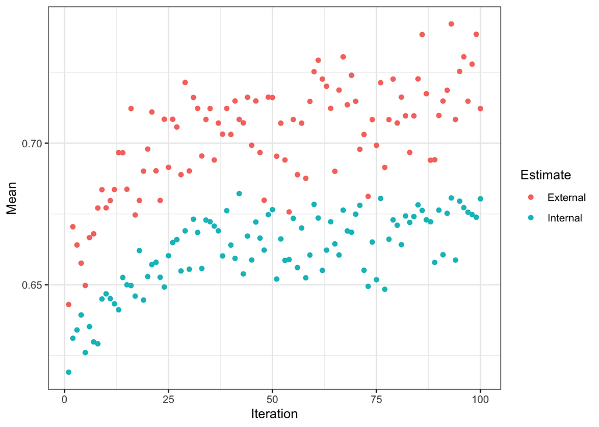

```r
# Plot performance over iterations:
plot(obj) + theme_bw()
```